# Predicting the FIFA World Cup’s Winner Using Machine Learning

## 3.8 Goals in the last fifteen matches:

The only way to be the World Champion is by scoring more goals than the rival. We can observe in the following graphs that teams that won a game, on average had more goals scored and fewer goals received in the last fifteen matches previous to the game.

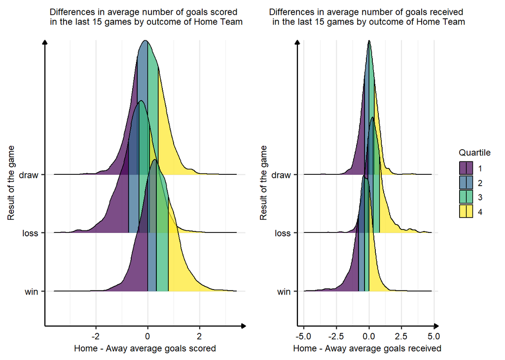

```r
s1 <- results %>%
  mutate(outcome = m15_goals_sc_dha ) %>%
  ggplot(aes(x = outcome, y = reorder(home_result, desc(home_result)), fill = factor(..quantile..))) +
    stat_density_ridges(quantiles = c(0.25,0.5,0.75)
                        , quantile_lines = TRUE
                        , geom = "density_ridges_gradient"
                        , alpha = 0.6
                        , scale = 2.3) +
  scale_fill_viridis(discrete = TRUE
                       , name = "Quartile"
                       , alpha = 0.7
                       , option = "viridis") + theme_per() +
   labs(title="Differences in average number of goals scored \n in the last 15 games by outcome of Home Team", x="Home - Away average goals scored" , y="Result of the game", fill= "Type") + theme(legend.position="none")

s2 <- results %>%
  mutate(outcome = m15_goals_rec_dha) %>%
  ggplot(aes(x = outcome, y = reorder(home_result, desc(home_result)), fill = factor(..quantile..))) +
    stat_density_ridges(quantiles = c(0.25,0.5,0.75)
                        , quantile_lines = TRUE
                        , geom = "density_ridges_gradient"
                        , alpha = 0.6
                        , scale = 2.3) +
  scale_fill_viridis(discrete = TRUE
                       , name = "Quartile"
                       , alpha = 0.7
                       , option = "viridis") + theme_per() +
    labs(title="Differences in average number of goals received \n in the last 15 games by outcome of Home Team", x="Home - Away average goals received" , y="Result of the game", fill= "Type") + theme(plot.title = element_text(hjust = 0.5))

# Plot
grid.arrange(s1, s2, ncol = 2)
```

# 4 References

- Cross, J., & Uhrig, R. (2023). Do Fans Impact Sports Outcomes? A COVID-19 Natural Experiment. Journal of Sports Economics, 24(1), 3–27.
[^1]: For each variable at home there is an away analogous and any share or mean is computed using data up to the previous game played for each team i.e I am always using lagged data
[^2]: Measured by the difference in the average FIFA ranking between opponents
[^3]: I did not change the order in those locations because as the data is scrapped from official sites, the order may be related to some proximity with the hosting country which will help to predict better the result